# Text Mining en Social Media: Analisis de Sentimiento en Twitter, Topic Covid

by [María Luisa Duque](https://www.linkedin.com/in/marialuisaduque/)

2020-06-16

## Análisis de sentimiento con datos de Twitter

Instalamos los paquetes requeridos.

```r
# Si queremos ejecutar este bloque de código hay que cambiar EVAL=TRUE o eliminar EVAL=FALSE
# install.packages("Rstem")
install.packages("~/TextMining/Rstem_0.4-1.tar.gz", repos = NULL, type = "source")
# install.packages("sentiment", repos = "http://www.omegahat.org/R", type = "source")
require(devtools)
# install.packages("Rstem", repos = "http://www.omegahat.org/R", type = "source")
# install.packages("~/TextMining/sentiment_0.2.tar.gz", repos = NULL, type = "source")
install_url("http://cran.r-project.org/src/contrib/Archive/sentiment/sentiment_0.2.tar.gz")
require(sentiment)
ls("package:sentiment")
install.packages("tm")
install.packages("wordcloud")
```

Cargamos las librerías.

```r
# library(twitteR)
library(rtweet)
library(wordcloud)
library(RColorBrewer)
library(plyr)
library(ggplot2)
library(sentiment) # Instalación local
library(sentimentr)
library(Rstem) # Instalación local
library(ggplot2)
library(gridExtra)
library(wordcloud)
library(igraph)
library(graphTweets)
library(tidyverse)
```

Antes de empezar hay que darse de alta en Twitter como desarrollador y registrar un App en el API: https://apps.twitter.com/

Con eso se pueden incluir los datos en este script o en otro fichero de extensión .R

- api_key <- “********************”
- api_secret <- “********************”
- access_token <- “********************”
- access_token_secret <- “********************”
- twitter_app <- “********************”

En nuestro caso los hemos incluido en el fichero twitterAuth3.R que está en nuestro directorio de trabajo (fichero no disponible o de acceso público, evidentemente, para poder replicar esta tarea deben lograr sus propios credenciales).

Cargamos el fichero y accedemos a Twitter.

```r
# Cargamos las credenciales
source('twitterAuth3.R')

# Accedemos a Titter a través de los datos del token
create_token(
  app             = twitter_app,
  consumer_key    = api_key,
  consumer_secret = api_secret,
  access_token    = access_token,
  access_secret   = access_token_secret)
```

```
## <Token>
## <oauth_endpoint>
##  request:   https://api.twitter.com/oauth/request_token
##  authorize: https://api.twitter.com/oauth/authenticate
##  access:    https://api.twitter.com/oauth/access_token
## <oauth_app> Clases_R_2018
##   key:    KpUn80ozM7vY9D6WVd5nmaibU
##   secret: <hidden>
## <credentials> oauth_token, oauth_token_secret
## ---
```

### Recopilación de tweets

La librería **rtweet** nos ofrece algunas funciones para sacar información general de Twitter, como:

```r
# Los emojis
emojis
```

```
## # A tibble: 2,623 x 2
##    code         description
##    <chr>        <chr>
##  1 "\U0001f600" grinning face
##  2 "\U0001f601" beaming face with smiling eyes
##  3 "\U0001f602" face with tears of joy
##  4 "\U0001f923" rolling on the floor laughing
##  5 "\U0001f603" grinning face with big eyes
##  6 "\U0001f604" grinning face with smiling eyes
##  7 "\U0001f605" grinning face with sweat
##  8 "\U0001f606" grinning squinting face
##  9 "\U0001f609" winking face
## 10 "\U0001f60a" smiling face with smiling eyes
## # ... with 2,613 more rows
```

Los lenguajes aceptados en Twitter.

```r
langs
```

```
## # A tibble: 486 x 5
##    bibliographic terminologic alpha english               french
##    <chr>         <chr>        <chr> <chr>                 <chr>
##  1 aar           <NA>         aa    Afar                  afar
##  2 abk           <NA>         ab    Abkhazian             abkhaze
##  3 ace           <NA>         <NA>  Achinese              aceh
##  4 ach           <NA>         <NA>  Acoli                 acoli
##  5 ada           <NA>         <NA>  Adangme               adangme
##  6 ady           <NA>         <NA>  Adyghe; Adygei        adyghé
##  7 afa           <NA>         <NA>  Afro-Asiatic languag~ afro-asiatiques, lang~
##  8 afh           <NA>         <NA>  Afrihili              afrihili
##  9 afr           <NA>         af    Afrikaans             afrikaans
## 10 ain           <NA>         <NA>  Ainu                  aïnou
## # ... with 476 more rows
```

Hacemos una petición de 18000 tweets haciendo uso de la query “covid”, la búsqueda q = “Covid” busca tweets que contengan “covid” ubicados en cualquier parte de los tweets y en cualquier orden. En español.

```r
covid_tweets <- search_tweets("covid", n = 18000, lang="es", include_rts = FALSE)
```

```
## Requesting token on behalf of user...
```

```
## Error: API user token required. see http://rtweet.info/articles/auth.html for instructions
```

Podemos guardarlos.

```r
save(covid_tweets, file = './data/covid_tweets_2020-06-07.RData')
```

```
## Error in save(covid_tweets, file = "./data/covid_tweets_2020-06-07.RData"): object 'covid_tweets' not found
```

En vez de sacar los datos de Twitter, podemos cargar el fichero.

```r
load("./data/covid_tweets_2020-06-07.RData")
```

Vemos el tamaño del objeto.

```r
dim(covid_tweets)
```

```
## [1] 17977    90
```

### Análsis de usuarios

Detalles de los usuarios que han producido los tweets que hemos capturado.

```r
users_data(covid_tweets) %>% head()
```

```
## # A tibble: 6 x 20
##   user_id screen_name name  location description url   protected followers_count
##   <chr>   <chr>       <chr> <chr>    <chr>       <chr> <lgl>               <int>
## 1 642526~ portal_luso Jorn~ "Bélgic~ ""          http~ FALSE                 172
## 2 816459~ nqn_notici~ Noti~ "Patago~ "Noticias ~ http~ FALSE                2957
## 3 276253~ pallaresmi~ Migu~ "Estado~ "DESDE EL ~ http~ FALSE                  76
## 4 120769~ JuanCar525~ JCFu~ ""       "la vida"   <NA>  FALSE                 337
## 5 120769~ JuanCar525~ JCFu~ ""       "la vida"   <NA>  FALSE                 337
## 6 120769~ JuanCar525~ JCFu~ ""       "la vida"   <NA>  FALSE                 337
## # ... with 12 more variables: friends_count <int>, listed_count <int>,
## #   statuses_count <int>, favourites_count <int>, account_created_at <dttm>,
## #   verified <lgl>, profile_url <chr>, profile_expanded_url <chr>,
## #   account_lang <lgl>, profile_banner_url <chr>, profile_background_url <chr>,
## #   profile_image_url <chr>
```

Usuarios más populares.

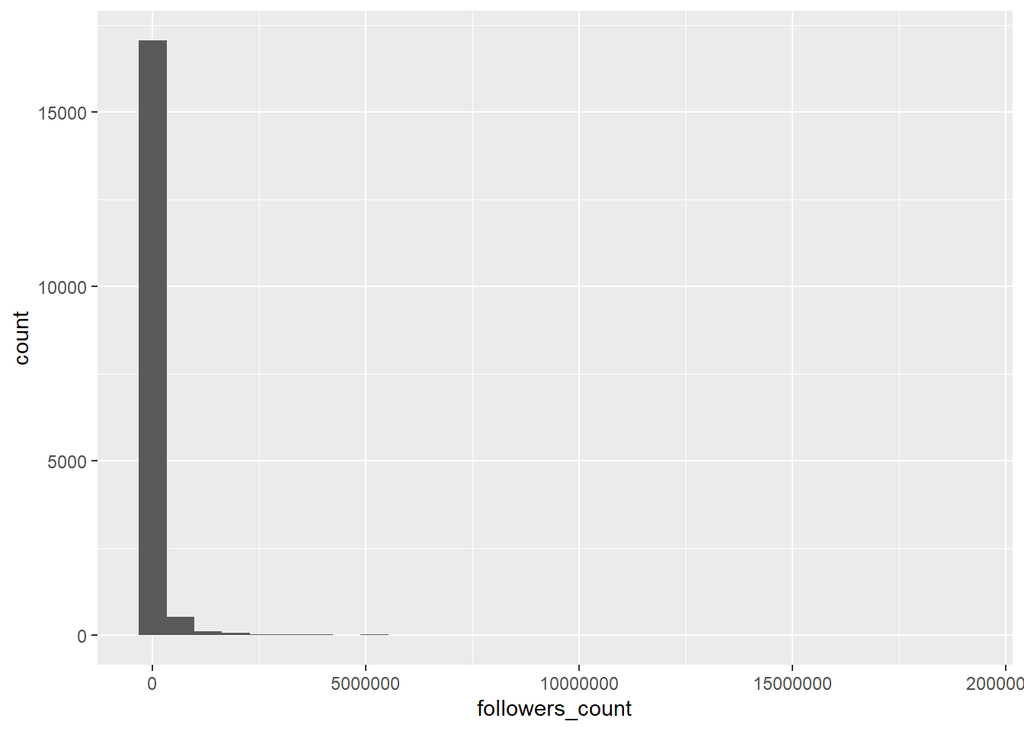

```r
options(scipen = 20)
ggplot(covid_tweets) +
    geom_histogram(aes(x = followers_count))
```

Top 5 de los usuarios más populares (con más seguidores), su procedencia y el contenido del tweet.

```r
covid_tweets %>%
    top_n(5, followers_count) %>%
    arrange(desc(followers_count)) %>%
    select(screen_name, followers_count, location, text)
```

```
## # A tibble: 6 x 4
##   screen_name   followers_count location    text
##   <chr>                   <int> <chr>       <chr>
## 1 CNNEE                18860257 En todas p~ Chile registra más de 5.000 nuevos ~
## 2 CNNEE                18860257 En todas p~ Varios jugadores de los Cowboys de ~
## 3 CNNEE                18860257 En todas p~ Tras nuevos picos de casos de covid~
## 4 CNNEE                18860257 En todas p~ OPINIÓN | En momentos tan complejos~
## 5 NoticiasCara~         8753764 Colombia    #Ampliación | Ceremonia de los Prem~
## 6 NoticiasCara~         8753764 Colombia    ¿Está su barrio entre ellos? Cinco ~
```

### Tweets más populares

En base a la cantidad de retweets que recibieron. Nos quedamos sólo con los tweets originales, descartando los que son retweets en sí mismos (“is_retweet == TRUE”) y revisamos la distribución de sus retweets.

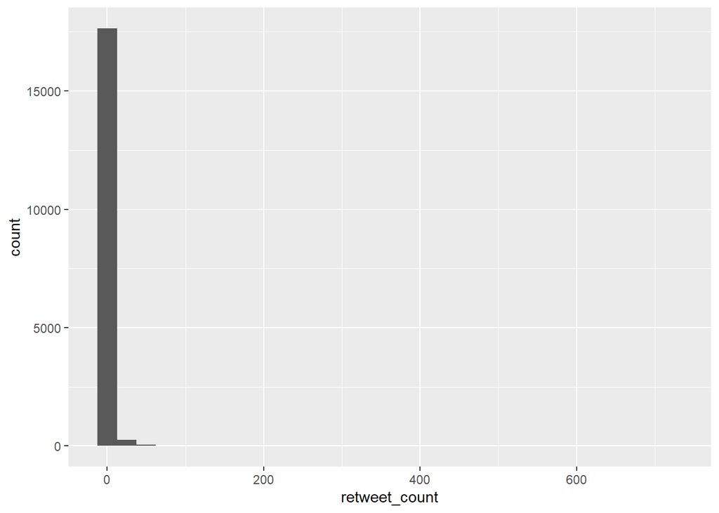

```r
ggplot(filter(covid_tweets, !is_retweet))+
    geom_histogram(aes(x = retweet_count))
```

Tweet original que sumó más retweets.

```r
covid_tweets %>%
    filter(!is_retweet) %>%
    filter(retweet_count == max(retweet_count)) %>%
    select(screen_name, retweet_count, followers_count, location, text)
```

```
## # A tibble: 1 x 5
##   screen_name retweet_count followers_count location text
##   <chr>               <int>           <int> <chr>    <chr>
## 1 elmundoes             722         3724401 España   El actor porno español Jor~
```

### Hora y día en la que se producen los tweets

*rtweet()* provee de una función que hace fácil mostrar la evolución temporal de nuestros tweets: ts_plot(). Podemos ver la frecuencia de tweets por segundo, hora, día, semana, mes o año eligiendo el parámetro correspondiente (“seconds”, “minutes”, “hours”, “days”, “weeks”, “months” o “years”).

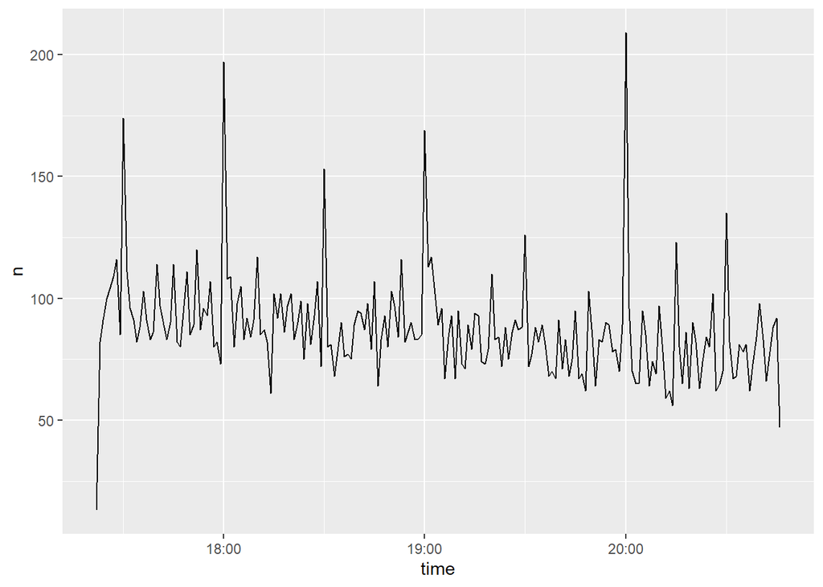

```r
ts_plot(covid_tweets, "minutes")
```

### Procedencia de los usuarios

Vamos a extraer el top 10 de los lugares más frecuentes, eliminando los tweets de usuarios sin datos en su atributo *location*.

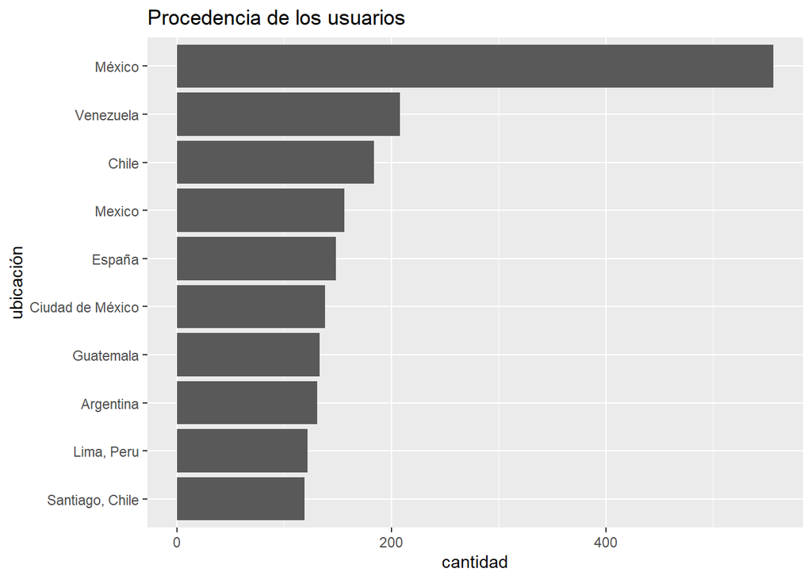

```r
covid_tweets %>%
    filter(location != "", !is.na(location)) %>%
    count(location) %>%
    top_n(10, n) %>%
    ggplot() +
      geom_col(aes(x = reorder(location, n), y = n)) +
      coord_flip() +
      labs(title = "Procedencia de los usuarios",
           x = "ubicación",
           y = "cantidad")
```

### Tweets en tiempo real

La función **stream_tweets()** permite iniciar una conexión y capturar tweets hasta que concluya el tiempo dispuesto por el parámetro *timeout*, expresado en segundos. Vamos a *escuchar* el stream de Twitter durante dos minutos (120 segundos), y capturar mensajes que incluyan la palabra *covid* en este caso.

```r
captura_streaming <- stream_tweets(q = "covid", timeout = 120, language = "es")
```

```
## Requesting token on behalf of user...
```

```
## Error: API user token required. see http://rtweet.info/articles/auth.html for instructions
```

```r
captura_streaming[4:5]
```

```
## Error in eval(expr, envir, enclos): objeto 'captura_streaming' no encontrado
```

### Emojis

Vamos a llevar un pequeño análisis/exploración sobre los emojis.

Instalamos el paquete requerido.

```r
devtools::install_github("GuangchuangYu/emojifont")
```

Cargamos la librería y buscamos el emoji deseado.

```r
library(emojifont)
search_emoji('smile')
```

```
## [1] "smiley"      "smile"       "sweat_smile" "smiley_cat"  "smile_cat"
```

```r
emoji(search_emoji('smile'))
```

```
## [1] "😃" "😄" "😅" "😺" "😸"
```

Para poder generar un gráfico de los emojis requerimos cargar emoji font.

Lista disponible de emoji fonts.

```r
list.emojifonts()
```

```
## [1] "EmojiOne.ttf"      "OpenSansEmoji.ttf"
```

Cargamos el emoji font seleccionado.

```r
load.emojifont('OpenSansEmoji.ttf')
```

Gráfico.

[figure not shown]

```r
set.seed(42)
x <- rnorm(10)
set.seed(321)
y <- rnorm(10)
plot(x, y, cex=0)
text(x, y, labels=emoji('cow'), cex=1.5, col='steelblue', family='OpenSansEmoji')
```

Gráfico con ggplo2.

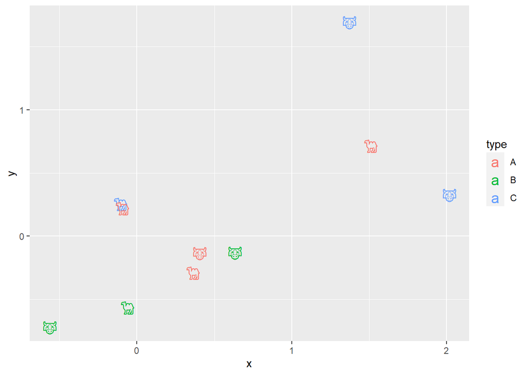

```r
d <- data.frame(x=x, y=y,
     label = sample(c(emoji('cow'), emoji('camel')), 10, replace=TRUE),
     type = sample(LETTERS[1:3], 10, replace=TRUE))
require(ggplot2)
ggplot(d, aes(x, y, color=type, label=label)) +
    geom_text(family="OpenSansEmoji", size=5)
```

Gráfico más útil con ggplot2.

```r
dd=data.frame(x=emoji(c("satisfied", "disapointed")), y=c(50, 10))
```

```
## Invalid: disapointed
```

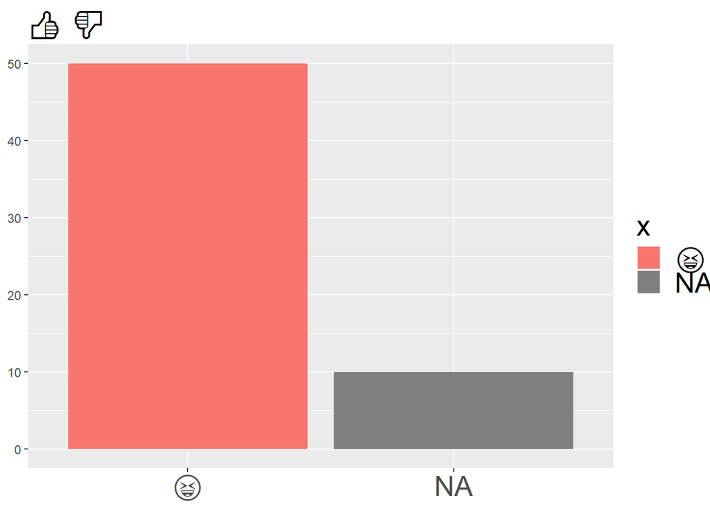

```r
emoji_text=element_text(family="OpenSansEmoji", size=20)
ggplot(dd, aes(x, y)) + geom_bar(stat='identity', aes(fill=x)) +
     ggtitle(paste(emoji(c("+1", "-1")), collapse=" "))+
     theme(axis.text.x = emoji_text, legend.text=emoji_text, title=emoji_text) +
     xlab(NULL)+ylab(NULL)
```

### ETL: Extract, transformation and load

Sacamos el texto.

```r
covid_txt <- covid_tweets$text
head(covid_txt, 10)
```

```
##  [1] "Covid-19: Transavia anuncia novas rotas de Montpellier para Faro e Porto https://t.co/oqRsU7PhXp"
##  [2] "El COVID 19 puede desencadenar diabetes en personas sanas https://t.co/uqJpbe2nqV"
##  [3] "NEBOT es cadaver POLITICO o CADAVER por COVID-19 alguna persona que entienda dé autopsias cosas del cura Sin cabezas @cdohrlancero @PatricioJijonL1 @Josernandez1 @AndsSalazar @rafaeloyarte @economista33 @ramirogarciaf @jaimenebotsaadi https://t.co/SKsEK6xwLI"
##  [4] "Alcalde bajese de la nube del Covid 19,  en la ciudad tiene que garantizar la vida e integridad de las personas que quieren expresar sus opiniones y  marchar pacificamente o acaso la policia no esta bajo su mando. Espera que vienen muchas marchas sociales mas https://t.co/m2qLkrqtvT"
##  [5] "Alcalde bajese de la nube del Covid 19,  en la ciudad tiene que garantizar la vida e integridad de las personas que quieren expresar sus opiniones y  marchar pacificamente o acaso la policia no esta bajo su mando. Espera que vienen muchas marchas sociales mas https://t.co/YlPmst9Mgh"
##  [6] "Alcalde bajese de la nube del Covid 19,  en la ciudad tiene que garantizar la vida e integridad de las personas que quieren expresar sus opiniones y  marchar pacificamente o acaso la policia no esta bajo su mando. Espera que vienen muchas marchas sociales mas https://t.co/om0pabRL6L"
##  [7] "Alcalde bajese de la nube del Covid 19,  en la ciudad tiene que garantizar la vida e integridad de las personas que quieren expresar sus opiniones y  marchar pacificamente o acaso la policia no esta bajo su mando. Espera que vienen muchas marchas sociales mas https://t.co/KXnRFoTiEs"
##  [8] "Alcalde bajese de la nube del Covid 19,  en la ciudad tiene que garantizar la vida e integridad de las personas que quieren expresar sus opiniones y  marchar pacificamente o acaso la policia no esta bajo su mando. Espera que vienen muchas marchas sociales mas https://t.co/58GY9LtYNR"
##  [9] "Alcalde bajese de la nube del Covid 19,  en la ciudad tiene que garantizar la vida e integridad de las personas que quieren expresar sus opiniones y  marchar pacificamente o acaso la policia no esta bajo su mando. Espera que vienen muchas marchas sociales mas https://t.co/EUKwibesFN"
## [10] "Alcalde bajese de la nube del Covid 19,  en la ciudad tiene que garantizar la vida e integridad de las personas que quieren expresar sus opiniones y  marchar pacificamente o acaso la policia no esta bajo su mando. Espera que vienen muchas marchas sociales mas https://t.co/TUTTWPlFsu"
```

Quitamos los retweets.

```r
covid_txt <- gsub("(RT|via)((?:\\b\\W*@\\w+)+)", "", covid_txt)
head(covid_txt, 10)
```

```
##  [1] "Covid-19: Transavia anuncia novas rotas de Montpellier para Faro e Porto https://t.co/oqRsU7PhXp"
##  [2] "El COVID 19 puede desencadenar diabetes en personas sanas https://t.co/uqJpbe2nqV"
##  [3] "NEBOT es cadaver POLITICO o CADAVER por COVID-19 alguna persona que entienda dé autopsias cosas del cura Sin cabezas @cdohrlancero @PatricioJijonL1 @Josernandez1 @AndsSalazar @rafaeloyarte @economista33 @ramirogarciaf @jaimenebotsaadi https://t.co/SKsEK6xwLI"
##  [4] "Alcalde bajese de la nube del Covid 19,  en la ciudad tiene que garantizar la vida e integridad de las personas que quieren expresar sus opiniones y  marchar pacificamente o acaso la policia no esta bajo su mando. Espera que vienen muchas marchas sociales mas https://t.co/m2qLkrqtvT"
##  [5] "Alcalde bajese de la nube del Covid 19,  en la ciudad tiene que garantizar la vida e integridad de las personas que quieren expresar sus opiniones y  marchar pacificamente o acaso la policia no esta bajo su mando. Espera que vienen muchas marchas sociales mas https://t.co/YlPmst9Mgh"
##  [6] "Alcalde bajese de la nube del Covid 19,  en la ciudad tiene que garantizar la vida e integridad de las personas que quieren expresar sus opiniones y  marchar pacificamente o acaso la policia no esta bajo su mando. Espera que vienen muchas marchas sociales mas https://t.co/om0pabRL6L"
##  [7] "Alcalde bajese de la nube del Covid 19,  en la ciudad tiene que garantizar la vida e integridad de las personas que quieren expresar sus opiniones y  marchar pacificamente o acaso la policia no esta bajo su mando. Espera que vienen muchas marchas sociales mas https://t.co/KXnRFoTiEs"
##  [8] "Alcalde bajese de la nube del Covid 19,  en la ciudad tiene que garantizar la vida e integridad de las personas que quieren expresar sus opiniones y  marchar pacificamente o acaso la policia no esta bajo su mando. Espera que vienen muchas marchas sociales mas https://t.co/58GY9LtYNR"
##  [9] "Alcalde bajese de la nube del Covid 19,  en la ciudad tiene que garantizar la vida e integridad de las personas que quieren expresar sus opiniones y  marchar pacificamente o acaso la policia no esta bajo su mando. Espera que vienen muchas marchas sociales mas https://t.co/EUKwibesFN"
## [10] "Alcalde bajese de la nube del Covid 19,  en la ciudad tiene que garantizar la vida e integridad de las personas que quieren expresar sus opiniones y  marchar pacificamente o acaso la policia no esta bajo su mando. Espera que vienen muchas marchas sociales mas https://t.co/TUTTWPlFsu"
```

Podemos quitar las personas (@), los usuarios, con el siguiente código.

```r
covid_txt <- gsub("@\\w+", "", covid_txt)
head(covid_txt, 10)
```

Quitamos los html, links.

```r
covid_txt <-  gsub("\\bhttp[a-zA-Z0-9]*\\b", "", covid_txt)
head(covid_txt, 10)
```

```
##  [1] "Covid-19: Transavia anuncia novas rotas de Montpellier para Faro e Porto ://t.co/oqRsU7PhXp"
##  [2] "El COVID 19 puede desencadenar diabetes en personas sanas ://t.co/uqJpbe2nqV"
##  [3] "NEBOT es cadaver POLITICO o CADAVER por COVID-19 alguna persona que entienda dé autopsias cosas del cura Sin cabezas @cdohrlancero @PatricioJijonL1 @Josernandez1 @AndsSalazar @rafaeloyarte @economista33 @ramirogarciaf @jaimenebotsaadi ://t.co/SKsEK6xwLI"
##  [4] "Alcalde bajese de la nube del Covid 19,  en la ciudad tiene que garantizar la vida e integridad de las personas que quieren expresar sus opiniones y  marchar pacificamente o acaso la policia no esta bajo su mando. Espera que vienen muchas marchas sociales mas ://t.co/m2qLkrqtvT"
##  [5] "Alcalde bajese de la nube del Covid 19,  en la ciudad tiene que garantizar la vida e integridad de las personas que quieren expresar sus opiniones y  marchar pacificamente o acaso la policia no esta bajo su mando. Espera que vienen muchas marchas sociales mas ://t.co/YlPmst9Mgh"
##  [6] "Alcalde bajese de la nube del Covid 19,  en la ciudad tiene que garantizar la vida e integridad de las personas que quieren expresar sus opiniones y  marchar pacificamente o acaso la policia no esta bajo su mando. Espera que vienen muchas marchas sociales mas ://t.co/om0pabRL6L"
##  [7] "Alcalde bajese de la nube del Covid 19,  en la ciudad tiene que garantizar la vida e integridad de las personas que quieren expresar sus opiniones y  marchar pacificamente o acaso la policia no esta bajo su mando. Espera que vienen muchas marchas sociales mas ://t.co/KXnRFoTiEs"
##  [8] "Alcalde bajese de la nube del Covid 19,  en la ciudad tiene que garantizar la vida e integridad de las personas que quieren expresar sus opiniones y  marchar pacificamente o acaso la policia no esta bajo su mando. Espera que vienen muchas marchas sociales mas ://t.co/58GY9LtYNR"
##  [9] "Alcalde bajese de la nube del Covid 19,  en la ciudad tiene que garantizar la vida e integridad de las personas que quieren expresar sus opiniones y  marchar pacificamente o acaso la policia no esta bajo su mando. Espera que vienen muchas marchas sociales mas ://t.co/EUKwibesFN"
## [10] "Alcalde bajese de la nube del Covid 19,  en la ciudad tiene que garantizar la vida e integridad de las personas que quieren expresar sus opiniones y  marchar pacificamente o acaso la policia no esta bajo su mando. Espera que vienen muchas marchas sociales mas ://t.co/TUTTWPlFsu"
```

Puntuación.

```r
covid_txt <- gsub("[[:punct:]]", "", covid_txt)
head(covid_txt, 10)
```

```
##  [1] "Covid19 Transavia anuncia novas rotas de Montpellier para Faro e Porto tcooqRsU7PhXp"
##  [2] "El COVID 19 puede desencadenar diabetes en personas sanas tcouqJpbe2nqV"
##  [3] "NEBOT es cadaver POLITICO o CADAVER por COVID19 alguna persona que entienda dé autopsias cosas del cura Sin cabezas cdohrlancero PatricioJijonL1 Josernandez1 AndsSalazar rafaeloyarte economista33 ramirogarciaf jaimenebotsaadi tcoSKsEK6xwLI"
##  [4] "Alcalde bajese de la nube del Covid 19  en la ciudad tiene que garantizar la vida e integridad de las personas que quieren expresar sus opiniones y  marchar pacificamente o acaso la policia no esta bajo su mando Espera que vienen muchas marchas sociales mas tcom2qLkrqtvT"
##  [5] "Alcalde bajese de la nube del Covid 19  en la ciudad tiene que garantizar la vida e integridad de las personas que quieren expresar sus opiniones y  marchar pacificamente o acaso la policia no esta bajo su mando Espera que vienen muchas marchas sociales mas tcoYlPmst9Mgh"
##  [6] "Alcalde bajese de la nube del Covid 19  en la ciudad tiene que garantizar la vida e integridad de las personas que quieren expresar sus opiniones y  marchar pacificamente o acaso la policia no esta bajo su mando Espera que vienen muchas marchas sociales mas tcoom0pabRL6L"
##  [7] "Alcalde bajese de la nube del Covid 19  en la ciudad tiene que garantizar la vida e integridad de las personas que quieren expresar sus opiniones y  marchar pacificamente o acaso la policia no esta bajo su mando Espera que vienen muchas marchas sociales mas tcoKXnRFoTiEs"
##  [8] "Alcalde bajese de la nube del Covid 19  en la ciudad tiene que garantizar la vida e integridad de las personas que quieren expresar sus opiniones y  marchar pacificamente o acaso la policia no esta bajo su mando Espera que vienen muchas marchas sociales mas tco58GY9LtYNR"
##  [9] "Alcalde bajese de la nube del Covid 19  en la ciudad tiene que garantizar la vida e integridad de las personas que quieren expresar sus opiniones y  marchar pacificamente o acaso la policia no esta bajo su mando Espera que vienen muchas marchas sociales mas tcoEUKwibesFN"
## [10] "Alcalde bajese de la nube del Covid 19  en la ciudad tiene que garantizar la vida e integridad de las personas que quieren expresar sus opiniones y  marchar pacificamente o acaso la policia no esta bajo su mando Espera que vienen muchas marchas sociales mas tcoTUTTWPlFsu"
```

Podríamos quitar palabras por nosotros elegidas del siguiente modo. Quitamos la palabra amp, en este caso.

```r
covid_txt <- gsub("amp", "", covid_txt)
head(covid_txt, 10)
```

Caracteres no alfanuméricos.

```r
covid_txt <- gsub("[^a-zA-Z0-9 ]", "", covid_txt)
head(covid_txt, 10)
```

```
##  [1] "Covid19 Transavia anuncia novas rotas de Montpellier para Faro e Porto tcooqRsU7PhXp"
##  [2] "El COVID 19 puede desencadenar diabetes en personas sanas tcouqJpbe2nqV"
##  [3] "NEBOT es cadaver POLITICO o CADAVER por COVID19 alguna persona que entienda d autopsias cosas del cura Sin cabezas cdohrlancero PatricioJijonL1 Josernandez1 AndsSalazar rafaeloyarte economista33 ramirogarciaf jaimenebotsaadi tcoSKsEK6xwLI"
##  [4] "Alcalde bajese de la nube del Covid 19  en la ciudad tiene que garantizar la vida e integridad de las personas que quieren expresar sus opiniones y  marchar pacificamente o acaso la policia no esta bajo su mando Espera que vienen muchas marchas sociales mas tcom2qLkrqtvT"
##  [5] "Alcalde bajese de la nube del Covid 19  en la ciudad tiene que garantizar la vida e integridad de las personas que quieren expresar sus opiniones y  marchar pacificamente o acaso la policia no esta bajo su mando Espera que vienen muchas marchas sociales mas tcoYlPmst9Mgh"
##  [6] "Alcalde bajese de la nube del Covid 19  en la ciudad tiene que garantizar la vida e integridad de las personas que quieren expresar sus opiniones y  marchar pacificamente o acaso la policia no esta bajo su mando Espera que vienen muchas marchas sociales mas tcoom0pabRL6L"
##  [7] "Alcalde bajese de la nube del Covid 19  en la ciudad tiene que garantizar la vida e integridad de las personas que quieren expresar sus opiniones y  marchar pacificamente o acaso la policia no esta bajo su mando Espera que vienen muchas marchas sociales mas tcoKXnRFoTiEs"
##  [8] "Alcalde bajese de la nube del Covid 19  en la ciudad tiene que garantizar la vida e integridad de las personas que quieren expresar sus opiniones y  marchar pacificamente o acaso la policia no esta bajo su mando Espera que vienen muchas marchas sociales mas tco58GY9LtYNR"
##  [9] "Alcalde bajese de la nube del Covid 19  en la ciudad tiene que garantizar la vida e integridad de las personas que quieren expresar sus opiniones y  marchar pacificamente o acaso la policia no esta bajo su mando Espera que vienen muchas marchas sociales mas tcoEUKwibesFN"
## [10] "Alcalde bajese de la nube del Covid 19  en la ciudad tiene que garantizar la vida e integridad de las personas que quieren expresar sus opiniones y  marchar pacificamente o acaso la policia no esta bajo su mando Espera que vienen muchas marchas sociales mas tcoTUTTWPlFsu"
```

Quitamos los tco. Los tco son un servicio que se usan para cortar los links. Direcciones cortas.

```r
covid_txt <-  gsub("\\btco[a-zA-Z0-9]*\\b", "", covid_txt)
head(covid_txt, 10)
```

```
##  [1] "Covid19 Transavia anuncia novas rotas de Montpellier para Faro e Porto "
##  [2] "El COVID 19 puede desencadenar diabetes en personas sanas "
##  [3] "NEBOT es cadaver POLITICO o CADAVER por COVID19 alguna persona que entienda d autopsias cosas del cura Sin cabezas cdohrlancero PatricioJijonL1 Josernandez1 AndsSalazar rafaeloyarte economista33 ramirogarciaf jaimenebotsaadi "
##  [4] "Alcalde bajese de la nube del Covid 19  en la ciudad tiene que garantizar la vida e integridad de las personas que quieren expresar sus opiniones y  marchar pacificamente o acaso la policia no esta bajo su mando Espera que vienen muchas marchas sociales mas "
##  [5] "Alcalde bajese de la nube del Covid 19  en la ciudad tiene que garantizar la vida e integridad de las personas que quieren expresar sus opiniones y  marchar pacificamente o acaso la policia no esta bajo su mando Espera que vienen muchas marchas sociales mas "
##  [6] "Alcalde bajese de la nube del Covid 19  en la ciudad tiene que garantizar la vida e integridad de las personas que quieren expresar sus opiniones y  marchar pacificamente o acaso la policia no esta bajo su mando Espera que vienen muchas marchas sociales mas "
##  [7] "Alcalde bajese de la nube del Covid 19  en la ciudad tiene que garantizar la vida e integridad de las personas que quieren expresar sus opiniones y  marchar pacificamente o acaso la policia no esta bajo su mando Espera que vienen muchas marchas sociales mas "
##  [8] "Alcalde bajese de la nube del Covid 19  en la ciudad tiene que garantizar la vida e integridad de las personas que quieren expresar sus opiniones y  marchar pacificamente o acaso la policia no esta bajo su mando Espera que vienen muchas marchas sociales mas "
##  [9] "Alcalde bajese de la nube del Covid 19  en la ciudad tiene que garantizar la vida e integridad de las personas que quieren expresar sus opiniones y  marchar pacificamente o acaso la policia no esta bajo su mando Espera que vienen muchas marchas sociales mas "
## [10] "Alcalde bajese de la nube del Covid 19  en la ciudad tiene que garantizar la vida e integridad de las personas que quieren expresar sus opiniones y  marchar pacificamente o acaso la policia no esta bajo su mando Espera que vienen muchas marchas sociales mas "
```

Quitamos NAs.

```r
covid_txt <- covid_txt[!is.na(covid_txt)]
head(covid_txt, 10)
```

```
##  [1] "Covid19 Transavia anuncia novas rotas de Montpellier para Faro e Porto "
##  [2] "El COVID 19 puede desencadenar diabetes en personas sanas "
##  [3] "NEBOT es cadaver POLITICO o CADAVER por COVID19 alguna persona que entienda d autopsias cosas del cura Sin cabezas cdohrlancero PatricioJijonL1 Josernandez1 AndsSalazar rafaeloyarte economista33 ramirogarciaf jaimenebotsaadi "
##  [4] "Alcalde bajese de la nube del Covid 19  en la ciudad tiene que garantizar la vida e integridad de las personas que quieren expresar sus opiniones y  marchar pacificamente o acaso la policia no esta bajo su mando Espera que vienen muchas marchas sociales mas "
##  [5] "Alcalde bajese de la nube del Covid 19  en la ciudad tiene que garantizar la vida e integridad de las personas que quieren expresar sus opiniones y  marchar pacificamente o acaso la policia no esta bajo su mando Espera que vienen muchas marchas sociales mas "
##  [6] "Alcalde bajese de la nube del Covid 19  en la ciudad tiene que garantizar la vida e integridad de las personas que quieren expresar sus opiniones y  marchar pacificamente o acaso la policia no esta bajo su mando Espera que vienen muchas marchas sociales mas "
##  [7] "Alcalde bajese de la nube del Covid 19  en la ciudad tiene que garantizar la vida e integridad de las personas que quieren expresar sus opiniones y  marchar pacificamente o acaso la policia no esta bajo su mando Espera que vienen muchas marchas sociales mas "
##  [8] "Alcalde bajese de la nube del Covid 19  en la ciudad tiene que garantizar la vida e integridad de las personas que quieren expresar sus opiniones y  marchar pacificamente o acaso la policia no esta bajo su mando Espera que vienen muchas marchas sociales mas "
##  [9] "Alcalde bajese de la nube del Covid 19  en la ciudad tiene que garantizar la vida e integridad de las personas que quieren expresar sus opiniones y  marchar pacificamente o acaso la policia no esta bajo su mando Espera que vienen muchas marchas sociales mas "
## [10] "Alcalde bajese de la nube del Covid 19  en la ciudad tiene que garantizar la vida e integridad de las personas que quieren expresar sus opiniones y  marchar pacificamente o acaso la policia no esta bajo su mando Espera que vienen muchas marchas sociales mas "
```

Podríamos quitar los emoticonos. No vamos a ejecutar este código (eval=FALSE).

```r
covid_txt <- iconv(covid_txt, 'UTF-8', 'ASCII')
head(covid_txt, 10)
```

Pasamos a minúsculas.

```r
covid_txt <- tolower(covid_txt)
head(covid_txt, 10)
```

```
##  [1] "covid19 transavia anuncia novas rotas de montpellier para faro e porto "
##  [2] "el covid 19 puede desencadenar diabetes en personas sanas "
##  [3] "nebot es cadaver politico o cadaver por covid19 alguna persona que entienda d autopsias cosas del cura sin cabezas cdohrlancero patriciojijonl1 josernandez1 andssalazar rafaeloyarte economista33 ramirogarciaf jaimenebotsaadi "
##  [4] "alcalde bajese de la nube del covid 19  en la ciudad tiene que garantizar la vida e integridad de las personas que quieren expresar sus opiniones y  marchar pacificamente o acaso la policia no esta bajo su mando espera que vienen muchas marchas sociales mas "
##  [5] "alcalde bajese de la nube del covid 19  en la ciudad tiene que garantizar la vida e integridad de las personas que quieren expresar sus opiniones y  marchar pacificamente o acaso la policia no esta bajo su mando espera que vienen muchas marchas sociales mas "
##  [6] "alcalde bajese de la nube del covid 19  en la ciudad tiene que garantizar la vida e integridad de las personas que quieren expresar sus opiniones y  marchar pacificamente o acaso la policia no esta bajo su mando espera que vienen muchas marchas sociales mas "
##  [7] "alcalde bajese de la nube del covid 19  en la ciudad tiene que garantizar la vida e integridad de las personas que quieren expresar sus opiniones y  marchar pacificamente o acaso la policia no esta bajo su mando espera que vienen muchas marchas sociales mas "
##  [8] "alcalde bajese de la nube del covid 19  en la ciudad tiene que garantizar la vida e integridad de las personas que quieren expresar sus opiniones y  marchar pacificamente o acaso la policia no esta bajo su mando espera que vienen muchas marchas sociales mas "
##  [9] "alcalde bajese de la nube del covid 19  en la ciudad tiene que garantizar la vida e integridad de las personas que quieren expresar sus opiniones y  marchar pacificamente o acaso la policia no esta bajo su mando espera que vienen muchas marchas sociales mas "
## [10] "alcalde bajese de la nube del covid 19  en la ciudad tiene que garantizar la vida e integridad de las personas que quieren expresar sus opiniones y  marchar pacificamente o acaso la policia no esta bajo su mando espera que vienen muchas marchas sociales mas "
```

Espacios, tabulaciones.

```r
covid_txt <- gsub("[ \t]{2,}", "", covid_txt)
covid_txt <- gsub("^\\s+|\\s+$", "", covid_txt)
head(covid_txt, 10)
```

```
##  [1] "covid19 transavia anuncia novas rotas de montpellier para faro e porto"
##  [2] "el covid 19 puede desencadenar diabetes en personas sanas"
##  [3] "nebot es cadaver politico o cadaver por covid19 alguna persona que entienda d autopsias cosas del cura sin cabezas cdohrlancero patriciojijonl1 josernandez1 andssalazar rafaeloyarte economista33 ramirogarciaf jaimenebotsaadi"
##  [4] "alcalde bajese de la nube del covid 19en la ciudad tiene que garantizar la vida e integridad de las personas que quieren expresar sus opiniones ymarchar pacificamente o acaso la policia no esta bajo su mando espera que vienen muchas marchas sociales mas"
##  [5] "alcalde bajese de la nube del covid 19en la ciudad tiene que garantizar la vida e integridad de las personas que quieren expresar sus opiniones ymarchar pacificamente o acaso la policia no esta bajo su mando espera que vienen muchas marchas sociales mas"
##  [6] "alcalde bajese de la nube del covid 19en la ciudad tiene que garantizar la vida e integridad de las personas que quieren expresar sus opiniones ymarchar pacificamente o acaso la policia no esta bajo su mando espera que vienen muchas marchas sociales mas"
##  [7] "alcalde bajese de la nube del covid 19en la ciudad tiene que garantizar la vida e integridad de las personas que quieren expresar sus opiniones ymarchar pacificamente o acaso la policia no esta bajo su mando espera que vienen muchas marchas sociales mas"
##  [8] "alcalde bajese de la nube del covid 19en la ciudad tiene que garantizar la vida e integridad de las personas que quieren expresar sus opiniones ymarchar pacificamente o acaso la policia no esta bajo su mando espera que vienen muchas marchas sociales mas"
##  [9] "alcalde bajese de la nube del covid 19en la ciudad tiene que garantizar la vida e integridad de las personas que quieren expresar sus opiniones ymarchar pacificamente o acaso la policia no esta bajo su mando espera que vienen muchas marchas sociales mas"
## [10] "alcalde bajese de la nube del covid 19en la ciudad tiene que garantizar la vida e integridad de las personas que quieren expresar sus opiniones ymarchar pacificamente o acaso la policia no esta bajo su mando espera que vienen muchas marchas sociales mas"
```

Vemos como nos ha quedado el texto.

El original.

```r
head(covid_tweets$text, 10)
```

```
##  [1] "Covid-19: Transavia anuncia novas rotas de Montpellier para Faro e Porto https://t.co/oqRsU7PhXp"
##  [2] "El COVID 19 puede desencadenar diabetes en personas sanas https://t.co/uqJpbe2nqV"
##  [3] "NEBOT es cadaver POLITICO o CADAVER por COVID-19 alguna persona que entienda dé autopsias cosas del cura Sin cabezas @cdohrlancero @PatricioJijonL1 @Josernandez1 @AndsSalazar @rafaeloyarte @economista33 @ramirogarciaf @jaimenebotsaadi https://t.co/SKsEK6xwLI"
##  [4] "Alcalde bajese de la nube del Covid 19,  en la ciudad tiene que garantizar la vida e integridad de las personas que quieren expresar sus opiniones y  marchar pacificamente o acaso la policia no esta bajo su mando. Espera que vienen muchas marchas sociales mas https://t.co/m2qLkrqtvT"
##  [5] "Alcalde bajese de la nube del Covid 19,  en la ciudad tiene que garantizar la vida e integridad de las personas que quieren expresar sus opiniones y  marchar pacificamente o acaso la policia no esta bajo su mando. Espera que vienen muchas marchas sociales mas https://t.co/YlPmst9Mgh"
##  [6] "Alcalde bajese de la nube del Covid 19,  en la ciudad tiene que garantizar la vida e integridad de las personas que quieren expresar sus opiniones y  marchar pacificamente o acaso la policia no esta bajo su mando. Espera que vienen muchas marchas sociales mas https://t.co/om0pabRL6L"
##  [7] "Alcalde bajese de la nube del Covid 19,  en la ciudad tiene que garantizar la vida e integridad de las personas que quieren expresar sus opiniones y  marchar pacificamente o acaso la policia no esta bajo su mando. Espera que vienen muchas marchas sociales mas https://t.co/KXnRFoTiEs"
##  [8] "Alcalde bajese de la nube del Covid 19,  en la ciudad tiene que garantizar la vida e integridad de las personas que quieren expresar sus opiniones y  marchar pacificamente o acaso la policia no esta bajo su mando. Espera que vienen muchas marchas sociales mas https://t.co/58GY9LtYNR"
##  [9] "Alcalde bajese de la nube del Covid 19,  en la ciudad tiene que garantizar la vida e integridad de las personas que quieren expresar sus opiniones y  marchar pacificamente o acaso la policia no esta bajo su mando. Espera que vienen muchas marchas sociales mas https://t.co/EUKwibesFN"
## [10] "Alcalde bajese de la nube del Covid 19,  en la ciudad tiene que garantizar la vida e integridad de las personas que quieren expresar sus opiniones y  marchar pacificamente o acaso la policia no esta bajo su mando. Espera que vienen muchas marchas sociales mas https://t.co/TUTTWPlFsu"
```

Y el limpio.

```r
head(covid_txt, 10)
```

```
##  [1] "covid19 transavia anuncia novas rotas de montpellier para faro e porto"
##  [2] "el covid 19 puede desencadenar diabetes en personas sanas"
##  [3] "nebot es cadaver politico o cadaver por covid19 alguna persona que entienda d autopsias cosas del cura sin cabezas cdohrlancero patriciojijonl1 josernandez1 andssalazar rafaeloyarte economista33 ramirogarciaf jaimenebotsaadi"
##  [4] "alcalde bajese de la nube del covid 19en la ciudad tiene que garantizar la vida e integridad de las personas que quieren expresar sus opiniones ymarchar pacificamente o acaso la policia no esta bajo su mando espera que vienen muchas marchas sociales mas"
##  [5] "alcalde bajese de la nube del covid 19en la ciudad tiene que garantizar la vida e integridad de las personas que quieren expresar sus opiniones ymarchar pacificamente o acaso la policia no esta bajo su mando espera que vienen muchas marchas sociales mas"
##  [6] "alcalde bajese de la nube del covid 19en la ciudad tiene que garantizar la vida e integridad de las personas que quieren expresar sus opiniones ymarchar pacificamente o acaso la policia no esta bajo su mando espera que vienen muchas marchas sociales mas"
##  [7] "alcalde bajese de la nube del covid 19en la ciudad tiene que garantizar la vida e integridad de las personas que quieren expresar sus opiniones ymarchar pacificamente o acaso la policia no esta bajo su mando espera que vienen muchas marchas sociales mas"
##  [8] "alcalde bajese de la nube del covid 19en la ciudad tiene que garantizar la vida e integridad de las personas que quieren expresar sus opiniones ymarchar pacificamente o acaso la policia no esta bajo su mando espera que vienen muchas marchas sociales mas"
##  [9] "alcalde bajese de la nube del covid 19en la ciudad tiene que garantizar la vida e integridad de las personas que quieren expresar sus opiniones ymarchar pacificamente o acaso la policia no esta bajo su mando espera que vienen muchas marchas sociales mas"
## [10] "alcalde bajese de la nube del covid 19en la ciudad tiene que garantizar la vida e integridad de las personas que quieren expresar sus opiniones ymarchar pacificamente o acaso la policia no esta bajo su mando espera que vienen muchas marchas sociales mas"
```

La diferencia, tras la limpieza, es sustancial.

### Clasificación de emociones

Empezamos clasificando emociones con *classify_emotion* usando un algoritmo de Bayes.

```r
covid_class_emo <- classify_emotion(covid_txt, algorithm="bayes", prior=1.0)
```

La función nos retorna 7 columnas: anger, disgust, fear, joy, sadness, surprise y best_fit para cada fila del documento

```r
head(covid_class_emo)
```

```
##      ANGER              DISGUST            FEAR
## [1,] "1.46871776464786" "3.09234031207392" "2.06783599555953"
## [2,] "1.46871776464786" "3.09234031207392" "2.06783599555953"
## [3,] "1.46871776464786" "3.09234031207392" "2.06783599555953"
## [4,] "1.46871776464786" "3.09234031207392" "2.06783599555953"
## [5,] "1.46871776464786" "3.09234031207392" "2.06783599555953"
## [6,] "1.46871776464786" "3.09234031207392" "2.06783599555953"
##      JOY                SADNESS           SURPRISE           BEST_FIT
## [1,] "1.02547755260094" "1.7277074477352" "2.78695866252273" NA
## [2,] "1.02547755260094" "1.7277074477352" "2.78695866252273" NA
## [3,] "1.02547755260094" "1.7277074477352" "2.78695866252273" NA
## [4,] "1.02547755260094" "1.7277074477352" "2.78695866252273" NA
## [5,] "1.02547755260094" "1.7277074477352" "2.78695866252273" NA
## [6,] "1.02547755260094" "1.7277074477352" "2.78695866252273" NA
```

Vamos a tratar de hacer un algoritmo de clasificación. La que según el algoritmo encaja mejor (BEST_FIT) la guardamos. Si bien, en ocasiones, no puede clasificar bien si la mayoría son NAs en el BEST_FIT.

```r
# Guardamos en el objeto emotion
emotion <- covid_class_emo[, 7]

# Y lo vemos en una tabla
table(emotion, useNA = 'ifany')
```

```
## emotion
##    anger  disgust     fear      joy  sadness surprise     <NA>
##     3800        2      812     1340      248      101    11674
```

Para facilitar la clasificación, vamos a substituir los NAs por unknown.

```r
emotion[is.na(emotion)] <- "unknown"
table(emotion, useNA = 'ifany')
```

```
## emotion
##    anger  disgust     fear      joy  sadness surprise  unknown
##     3800        2      812     1340      248      101    11674
```

En un gráfico.

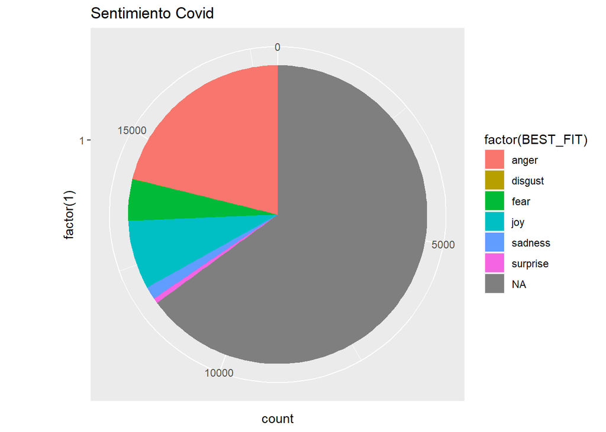

```r
pie <- ggplot(as.data.frame(covid_class_emo), aes(x = factor(1), fill = factor(BEST_FIT))) +
 geom_bar(width = 1)
pie + coord_polar(theta = "y") + labs(title = 'Sentimiento Covid')
```

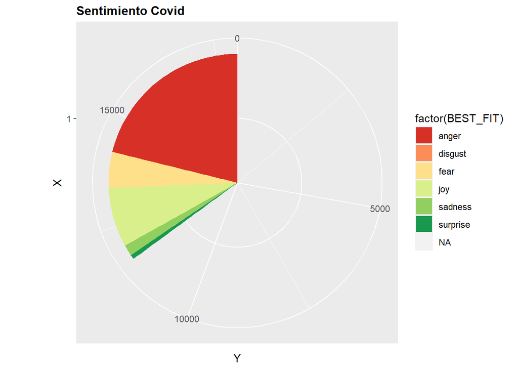

```r
pie <- ggplot(as.data.frame(covid_class_emo), aes(x = factor(1), fill = factor(BEST_FIT)))  + geom_bar(width = 1)

pie + coord_polar(theta = "y") + ggtitle("Sentimiento Covid") + ylab("Y") + xlab("X") + scale_fill_brewer(palette = "RdYlGn") + theme(plot.title = element_text(size=12, face='bold'))
```

Barras.

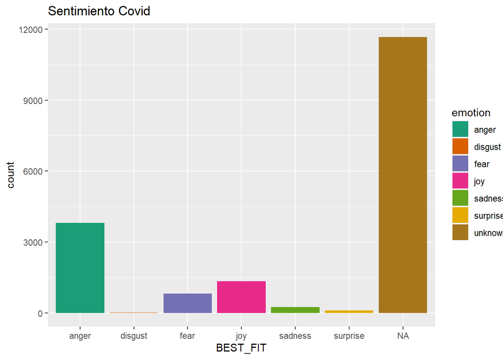

```r
g <- ggplot(as.data.frame(covid_class_emo), aes(x = BEST_FIT)) +
 geom_bar() + labs(title = 'Sentimiento Covid') + geom_bar(aes(y=..count.., fill=emotion)) +
      scale_fill_brewer(palette="Dark2")
g
```

Obtenemos la **polaridad**. Clasificamos el texto en cuatro categorías.

- POS: Sentimiento positivo
- NEG: Sentimiento negativo
- POS/NEG: No definido
- BEST_FIT: La mas probable

```r
covid_class_pol <- classify_polarity(covid_txt, algorithm="bayes")
head(covid_class_pol, 3)
```

```
##      POS                NEG                 POS/NEG             BEST_FIT
## [1,] "1.03127774142571" "0.445453222112551" "2.31512017476245"  "positive"
## [2,] "1.03127774142571" "0.445453222112551" "2.31512017476245"  "positive"
## [3,] "8.78232285939751" "9.47547003995745"  "0.926848253686942" "negative"
```

Como antes, creamos un objeto con el resultado, en este caso la polaridad.

```r
polarity <- covid_class_pol[, 4]
head(polarity)
```

```
## [1] "positive" "positive" "negative" "positive" "positive" "positive"
```

En una tabla.

```r
table(polarity, useNA = 'ifany')
```

```
## polarity
## negative  neutral positive
##     3021     1067    13889
```

Recopilamos la información en un dataframe.

```r
sentiment_dataframe <- data.frame(text     = covid_txt,
                                  emotion  = emotion,
                                  polarity = polarity, stringsAsFactors=FALSE)
#head(sentiment_dataframe)
```

Lo reordenamos (decreciente).

```r
sentiment_dataframe <- within(sentiment_dataframe, emotion <- factor(emotion, levels=names(sort(table(emotion), decreasing=TRUE))))
#head(sentiment_dataframe)
```

Nombres de las variables.

```r
names(sentiment_dataframe)
```

```
## [1] "text"     "emotion"  "polarity"
```

Estructura del dataframe.

```r
str(sentiment_dataframe)
```

```
## 'data.frame':    17977 obs. of  3 variables:
##  $ text    : chr  "covid19 transavia anuncia novas rotas de montpellier para faro e porto" "el covid 19 puede desencadenar diabetes en personas sanas" "nebot es cadaver politico o cadaver por covid19 alguna persona que entienda d autopsias cosas del cura sin cabe"| __truncated__ "alcalde bajese d…
##  $ emotion : Factor w/ 7 levels "unknown","anger",..: 1 1 1 1 1 1 1 1 1 1 ...
##  $ polarity: chr  "positive" "positive" "negative" "positive" ...
```

Resumen del dataframe.

```r
summary(sentiment_dataframe)
```

```
##      text               emotion        polarity
##  Length:17977       unknown :11674   Length:17977
##  Class :character   anger   : 3800   Class :character
##  Mode  :character   joy     : 1340   Mode  :character
##                     fear    :  812
##                     sadness :  248
##                     surprise:  101
##                     disgust :    2
```

### Gráficos

Número de Tweets clasificados por categorías.

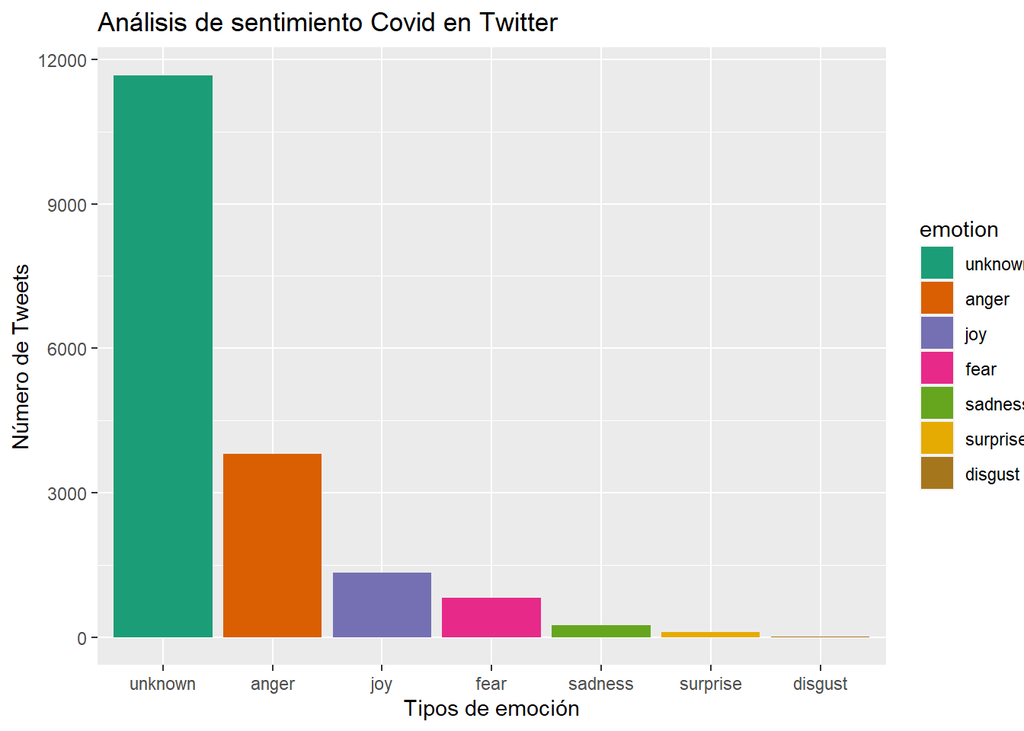

```r
ggplot(sentiment_dataframe, aes(x = emotion)) + geom_bar(aes(y = ..count.., fill = emotion)) +
      scale_fill_brewer(palette = "Dark2") +
      ggtitle("Análisis de sentimiento Covid en Twitter") +
      theme(legend.position="right") + ylab("Número de Tweets") + xlab("Tipos de emoción")
```

Gráfico de Polaridad por tweets.

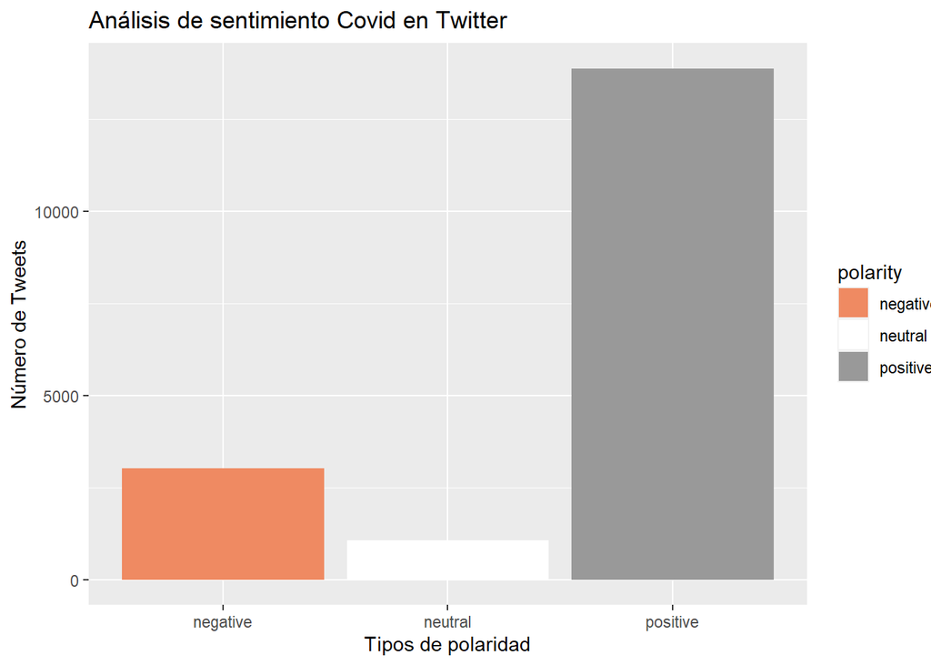

```r
ggplot(sentiment_dataframe, aes(x = polarity)) +
      geom_bar(aes(y = ..count.., fill = polarity)) +
      scale_fill_brewer(palette = "RdGy") +
      ggtitle("Análisis de sentimiento Covid en Twitter") +
      theme(legend.position="right") + ylab("Número de Tweets") + xlab("Tipos de polaridad")
```

Separamos las palabras según las emociones.

```r
covid_emos     <- levels(factor(sentiment_dataframe$emotion))
n_covid_emos   <- length(covid_emos)
covid_emo_docs <- rep("", n_covid_emos)
for (i in 1:n_covid_emos)
{
      tmp <- covid_txt[emotion == covid_emos[i]]
      covid_emo_docs[i] <- paste(tmp, collapse=" ")
}
```

Las vemos.

```r
head(covid_emos)
```

```
## [1] "unknown"  "anger"    "joy"      "fear"     "sadness"  "surprise"
```

### Wordclouds: Nubes de palabras

Finalmente, veamos las palabras en los tweets y creamos una nube de palabras que usa las emociones de las palabras para determinar su ubicación dentro de la nube.

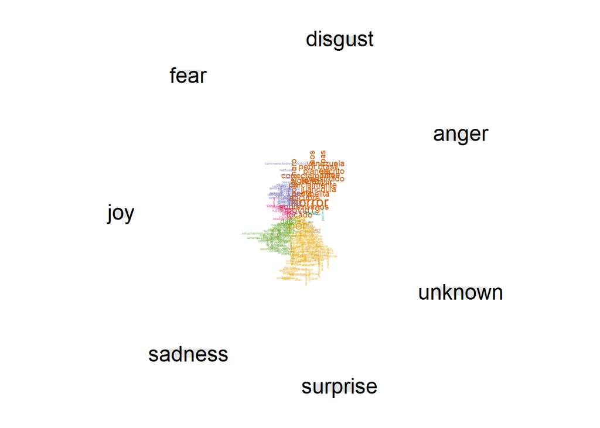

```r
covid_sentiment_df = data.frame(text=covid_txt, emotion=emotion,
polarity=polarity, stringsAsFactors=FALSE)

# Separamos el texto segun las emociones
emotion_covid = levels(factor(covid_sentiment_df$emotion))
emotion_length = length(emotion_covid)
emotion_covid.docs = rep('', emotion_length)
for (i in 1: emotion_length)
{
tmp = covid_txt[emotion == emotion_covid[i]]
emotion_covid.docs[i] = paste(tmp, collapse=' ')
}

# Eliminamos las Stopwords
emotion_covid.docs = removeWords(emotion_covid.docs, stopwords('es'))

# Creamos el corpus
corpus = Corpus(VectorSource(emotion_covid.docs))
tdm = TermDocumentMatrix(corpus)
tdm = as.matrix(tdm)
colnames(tdm) = emotion_covid

# Dibujamos una Comparison Wordcloud
comparison.cloud(tdm, colors = brewer.pal(emotion_length, 'Dark2'),
scale = c(1,.2), max.words = 300,random.order = FALSE, title.size = 1.5)
```

La presente nube de palabras no parece verse correctamente al ser renderizada. Vamos a mostrarla una vez salvada la imagen.

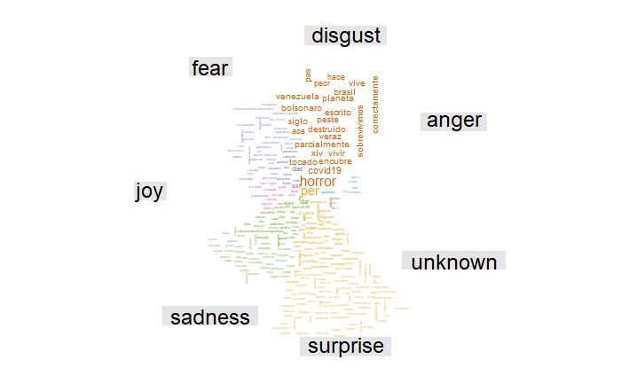

WordCloud1

#### Corpus

Creamos un corpus.

```r
covid_corpus <- Corpus(VectorSource(covid_txt))
inspect(covid_corpus[1:10])
```

```
## <<SimpleCorpus>>
## Metadata:  corpus specific: 1, document level (indexed): 0
## Content:  documents: 10
##
##  [1] covid19 transavia anuncia novas rotas de montpellier para faro e porto
##  [2] el covid 19 puede desencadenar diabetes en personas sanas
##  [3] nebot es cadaver politico o cadaver por covid19 alguna persona que entienda d autopsias cosas del cura sin cabezas cdohrlancero patriciojijonl1 josernandez1 andssalazar rafaeloyarte economista33 ramirogarciaf jaimenebotsaadi
##  [4] alcalde bajese de la nube del covid 19en la ciudad tiene que garantizar la vida e integridad de las personas que quieren expresar sus opiniones ymarchar pacificamente o acaso la policia no esta bajo su mando espera que vienen muchas marchas sociales mas
##  [5] alcalde bajese de la nube del covid 19en la ciudad tiene que garantizar la vida e integridad de las personas que quieren expresar sus opiniones ymarchar pacificamente o acaso la policia no esta bajo su mando espera que vienen muchas marchas sociales mas
##  [6] alcalde bajese de la nube del covid 19en la ciudad tiene que garantizar la vida e integridad de las personas que quieren expresar sus opiniones ymarchar pacificamente o acaso la policia no esta bajo su mando espera que vienen muchas marchas sociales mas
##  [7] alcalde bajese de la nube del covid 19en la ciudad tiene que garantizar la vida e integridad de las personas que quieren expresar sus opiniones ymarchar pacificamente o acaso la policia no esta bajo su mando espera que vienen muchas marchas sociales mas
##  [8] alcalde bajese de la nube del covid 19en la ciudad tiene que garantizar la vida e integridad de las personas que quieren expresar sus opiniones ymarchar pacificamente o acaso la policia no esta bajo su mando espera que vienen muchas marchas sociales mas
##  [9] alcalde bajese de la nube del covid 19en la ciudad tiene que garantizar la vida e integridad de las personas que quieren expresar sus opiniones ymarchar pacificamente o acaso la policia no esta bajo su mando espera que vienen muchas marchas sociales mas
## [10] alcalde bajese de la nube del covid 19en la ciudad tiene que garantizar la vida e integridad de las personas que quieren expresar sus opiniones ymarchar pacificamente o acaso la policia no esta bajo su mando espera que vienen muchas marchas sociales mas
```

Lo limpiamos con *tm_map*.

```r
# Pasamos a minúsculas
corpus_clean <- tm_map(covid_corpus, tolower)
# Quitamos los números
corpus_clean <- tm_map(corpus_clean, removeNumbers)
# Quitamos puntauación
corpus_clean <- tm_map(corpus_clean, removePunctuation)
# Quitamos stopwords
corpus_clean <- tm_map(corpus_clean, removeWords, stopwords("es"))
# Quitamos espacios en blanco
corpus_clean <- tm_map(corpus_clean, stripWhitespace)
```

Generamos un dtm (Document-Term Matrix). Para ver cuántas veces aparecen las palabras en el documento.

```r
covid_dtm <- DocumentTermMatrix(covid_corpus, control = list(minWordLength = 1,
                                                       stopwords = TRUE))
inspect(covid_dtm)
```

```
## <<DocumentTermMatrix (documents: 17977, terms: 49271)>>
## Non-/sparse entries: 298055/885446712
## Sparsity           : 100%
## Maximal term length: 215
## Weighting          : term frequency (tf)
## Sample             :
##        Terms
## Docs    con covid covid19 del las los para por que una
##   10205   0     0       1   0   0   0    0   0   0   0
##   10757   1     1       0   0   0   1    0   1   3   0
##   12981   0     1       0   0   1   0    0   1   0   0
##   13371   0     1       0   0   0   0    1   0   2   1
##   13372   0     1       0   1   0   1    0   0   0   0
##   13373   1     1       0   1   0   1    1   0   1   1
##   4557    0     0       1   1   2   1    0   1   0   0
##   858     2     1       0   0   1   3    0   1   2   0
##   9283    0     1       0   0   0   0    1   0   0   0
##   9457    2     1       0   1   0   1    0   2   1   1
```

Hacemos el stem.

```r
covid_corpus_stem <- tm_map(covid_corpus, stemDocument)
covid_corpus_stem <- tm_map(covid_corpus_stem, stemCompletion, dictionary = covid_corpus)
inspect(covid_corpus_stem[1:5])
```

```
## <<SimpleCorpus>>
## Metadata:  corpus specific: 1, document level (indexed): 0
## Content:  documents: 5
##
##                                                                                                                                                                                 covid19 transavia anuncia nova rota de montpelli para faro e porto
##
##                                                                                                                                                                                               el covid 19 pued desencadenar diabet en persona sana
##
##                           nebot es cadav politico o cadav por covid19 alguna persona que entienda d autopsia cosa del cura sin cabeza cdohrlancero patriciojijonl1 josernandez1 andssalazar rafaeloyart economista33 ramirogarciaf jaimenebotsaadi
##
## alcald bajes de la nube del covid 19en la ciudad tien que garantizar la vida e integridad de las persona que quieren expresar sus opinion ymarchar pacificament o acaso la policia no esta bajo su mando espera que vienen mucha marcha social mas
##
## alcald bajes de la nube del covid 19en la ciudad tien que garantizar la vida e integridad de las persona que quieren expresar sus opinion ymarchar pacificament o acaso la policia no esta bajo su mando espera que vienen mucha marcha social mas
##
```

Observamos los términos más frecuentes. Ponemos la frecuencia mínima de 10, en un “head” que nos devuelva los 40 primeros.

```r
head(findFreqTerms(covid_dtm, lowfreq=10), 40)
```

```
##  [1] "anuncia"       "covid19"       "para"          "covid"
##  [5] "diabetes"      "personas"      "puede"         "alguna"
##  [9] "cosas"         "cura"          "del"           "persona"
## [13] "por"           "que"           "sin"           "19en"
## [17] "acaso"         "alcalde"       "bajese"        "bajo"
## [21] "ciudad"        "espera"        "esta"          "expresar"
## [25] "garantizar"    "integridad"    "las"           "mando"
## [29] "marchas"       "mas"           "muchas"        "nube"
## [33] "opiniones"     "pacificamente" "policia"       "quieren"
## [37] "sociales"      "sus"           "tiene"         "vida"
```

**Segunda wordcloud: Nube de palabras.**

Generamos una segunda nube de palabras más genérica.

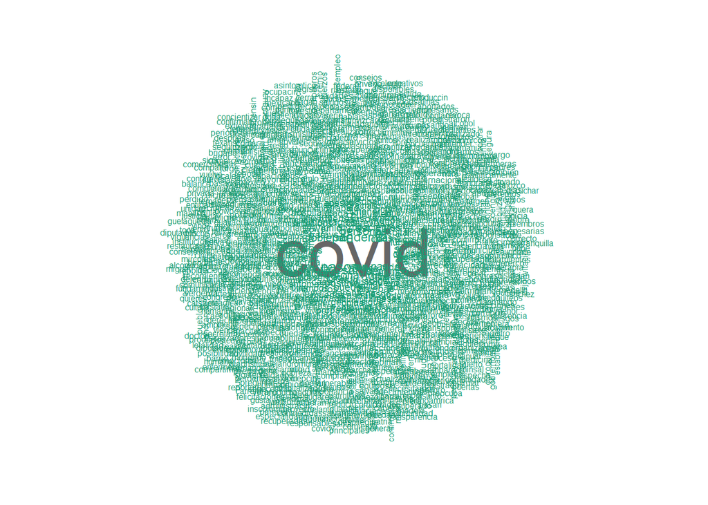

```r
wordcloud(corpus_clean, min.freq = 30, random.order = FALSE, colors = brewer.pal(8, "Dark2"))
```

La presente nube de palabras no parece verse correctamente al ser renderizada. Vamos a mostrarla una vez salvada la imagen.

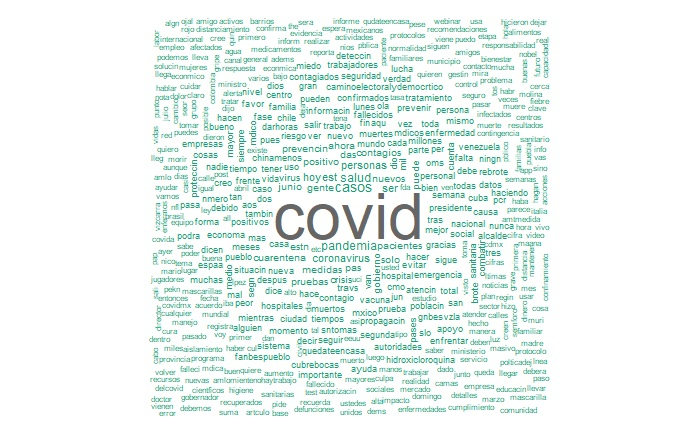

WordCloud2

### Obtención de las tendencias

Para un momento determinado, el actual en el momento de ejecución del presente código, las tendencias disponibles serían.

```r
# Del paquete twitteR
# availableTrendLocations()

# Con el paquete rtweet
get_trends()
```

```
## Requesting token on behalf of user...
```

```
## Error: API user token required. see http://rtweet.info/articles/auth.html for instructions
```

Y también las podemos obtener por localización, en este caso se usa el ID WOEID.

```r
# Del paquete rtweet
tendencias_locales <- trends_available()
```

```
## Requesting token on behalf of user...
```

```
## Error: API user token required. see http://rtweet.info/articles/auth.html for instructions
```

```r
head(tendencias_locales)
```

```
## Error in head(tendencias_locales): objeto 'tendencias_locales' no encontrado
```

Vemos la tabla por países.

```r
table(tendencias_locales$countryCode)
```

```
## Error in table(tendencias_locales$countryCode): objeto 'tendencias_locales' no encontrado
```

Para España.

```r
tendencias_locales[tendencias_locales$countryCode=='ES', ]
```

```
## Error in eval(expr, envir, enclos): objeto 'tendencias_locales' no encontrado
```

Vemos que España es el woeid 23424950, vemos las tendencias en España.

```r
get_trends(woeid = '23424950')
```

```
## Requesting token on behalf of user...
```

```
## Error: API user token required. see http://rtweet.info/articles/auth.html for instructions
```

### Referencias, Comentarios y Links

**Referencias**

Parte de este código ha sido recopilado de las lecciones del profesor [Santiago Mota](https://www.linkedin.com/in/santiagomota/), Master in Big Data and & Data Science at Complutense University of Madrid, que a su vez ha sido inspirado de la documentación [Join, split, and compress PDF files with pdftools](https://www.r-bloggers.com/join-split-and-compress-pdf-files-with-pdftools/).

**Links**

- Ejemplo de carga de fichero y acceso a Twitter, [aqui.](https://colinpriest.com/2015/07/04/tutorial-using-r-and-twitter-to-analyse-consumer-sentiment/)
- Ejemplo conectando R a Twitter [aqui.](https://rpubs.com/HAVB/rtweet)
- Información sobre exploración de emojis [aqui,](https://yulab-smu.github.io/treedata-book/chapter8.html#phylomoji) o vía CRAN [aqui.](https://cran.rstudio.com/web/packages/emojifont/index.html)

**Comentarios**

El presente código ha sido ejecutado en el sistema operativo version Windows 10, 64 bits, escogiendo formato de codificación en RStudio UTF-8.

A work by [María Luisa Duque](https://www.linkedin.com/in/marialuisaduque/)

*marialdu@umc.es*